# March Madness, idk

Author

Micah Pew, Benjamin Andreasen

```r
library(tidyverse)
library(rvest)
library(stringr)
library(scales)
```

## Import

- We took our data from 2 different sources. The first was gathered and published on Kaggle, the second we gathered ourselves from **TeamRankings.**
- Our original import used this series of functions to scrape from **TeamRankings**:

```r
# vector of season_end_dates (season starting in 1999 through season starting in 2023)
dates_08_to_23 <- c(
  '04-09-2024', '04-04-2023', '04-05-2022', '04-06-2021', '03-12-2020',
  '04-09-2019', '04-03-2018', '04-04-2017', '04-05-2016',
  '04-06-2015', '04-07-2014', '04-08-2013', '04-02-2012',
  '04-04-2011', '04-03-2010', '04-06-2009', '04-07-2008'
  )

generate_df <- function( base_url, season_end_dates ) {
  # returns single df containing all data from the tables at base_url and for the seasons in season_end_dates

    construct_urls <- function( base_url , season_end_dates ) {
      # construct URLs for the given base URL and season end dates

      return(
        lapply( season_end_dates , function( season_end_date ) {
          paste0( base_url , '?date=' , season_end_date ) } )
      )
    }

    scrape_html_table <- function( url ) {
      # returns html table contained at given url

      return(
        read_html( url ) |>
          html_element( 'table' ) |>
          html_table() |>
          as_tibble()
      )
    }

    clean_list <- function( df ) {
      colnames( df )[ c( 3 , 8 ) ] <- c( "November-December" , "January-April" )
      df[ , 3 : 8 ] <- lapply( df[ ,  3 : 8 ] , as.numeric )
      return( df )
    }

  constructed_urls <- construct_urls( base_url , season_end_dates ) # list of urls: the given base_url with all the '?date=' endings added

  scraped_list <- lapply( constructed_urls , scrape_html_table ) # list of lists: each one has the contents of the html table found at one of the above urls

  cleaned_list <- lapply( scraped_list , clean_list ) # same list of lists: col names and types cleaned

  desired_df <- bind_rows( cleaned_list ) # df: df made from list of lists

  desired_df <- desired_df |>
    mutate( Season = rep( season_end_dates , sapply( scraped_list , nrow ) ) ) |>
    mutate( Season = as.double( substr( Season , 7 , 10 ) ) ) # add Season column

  return( desired_df )
}

# example usage
ppg_df <- generate_df( 'https://www.teamrankings.com/ncaa-basketball/stat/points-per-game' , dates_08_to_23 )
```

- However, as is best practice, we have already done so and saved the dataframes locally. We found it convenient to combine data from both **Kaggle** and **TeamRankings** externally. So, now we can just read in our clean, pretty data:

```r
seed_results <- read_csv( 'generated_dfs/Seed_Results.csv' )
away_neutral <- read_csv( 'generated_dfs/Away_Neutral_Stats.csv' )
home <- read_csv( 'generated_dfs/Home_Stats.csv' )
conf_results <- read_csv( 'generated_dfs/Conference_Results.csv' )
scoring_margins <- read_csv( 'generated_dfs/scoring_margins.csv' )
```

## Wrangling

- Wrangling was partially done at Import, with the web scraping functions, but Micah had to do a lot of work after the fact. For example, the Kaggle data had an entire season’s worth of seeding missing, so Micah had to add them by hand.

# Plots

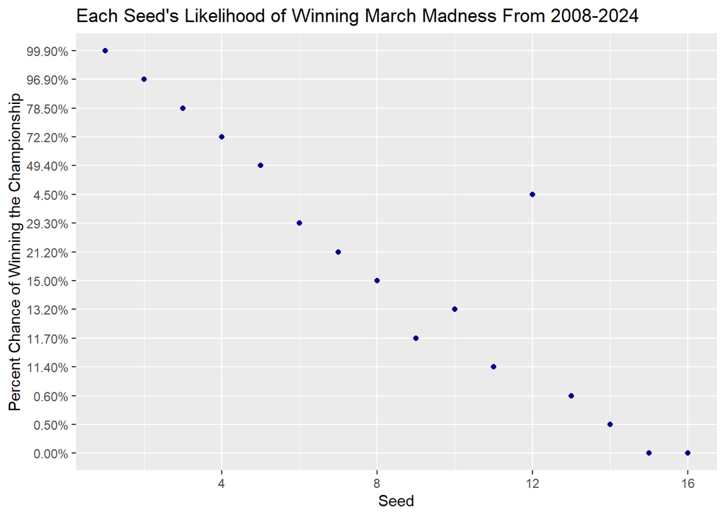

```r
#Create a scatterplot showing relationship between seed and how likely they are to win a championship
ggplot(seed_results, aes(x = Seed, y = `CHAMP%`))+
  geom_point(color = "darkblue")+
  labs(
    title = "Each Seed's Likelihood of Winning March Madness From 2008-2024",
    x = "Seed",
    y = "Percent Chance of Winning the Championship"
  )
```

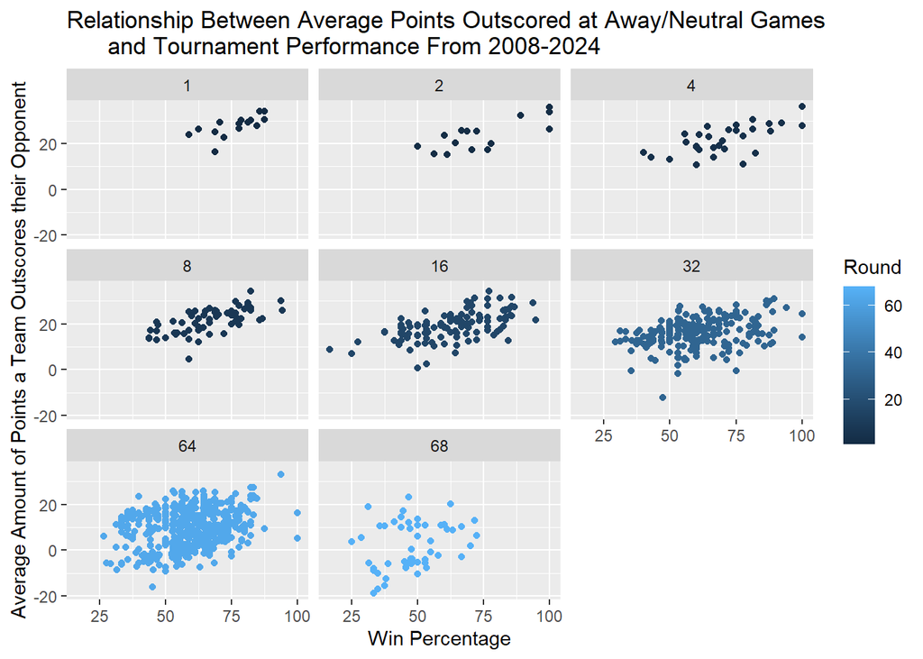

```r
#Create a series of plots to show the relationship between how teams perform at away/neutral
#site games druing the regular season and how they perform in the tournament
ggplot(away_neutral, aes(x = WinPercent, y = Outscore, color = Round))+
  geom_point()+
  labs(
    title = "Relationship Between Average Points Outscored at Away/Neutral Games
      and Tournament Performance From 2008-2024",
    x = "Win Percentage",
    y = "Average Amount of Points a Team Outscores their Opponent"
  )+
  facet_wrap(~Round)
```

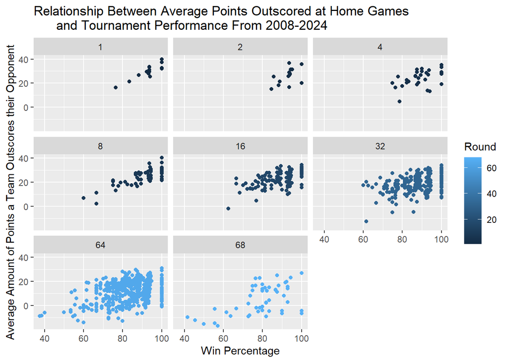

```r
#Create a series of plots to show the relationship between how teams perform at home
#site games druing the regular season and how they perform in the tournament
ggplot(home, aes(x = WinPercent, y = Outscore, color = Round))+
  geom_point()+
  labs(
    title = "Relationship Between Average Points Outscored at Home Games
      and Tournament Performance From 2008-2024",
    x = "Win Percentage",
    y = "Average Amount of Points a Team Outscores their Opponent"
  )+
  facet_wrap(~Round)
```

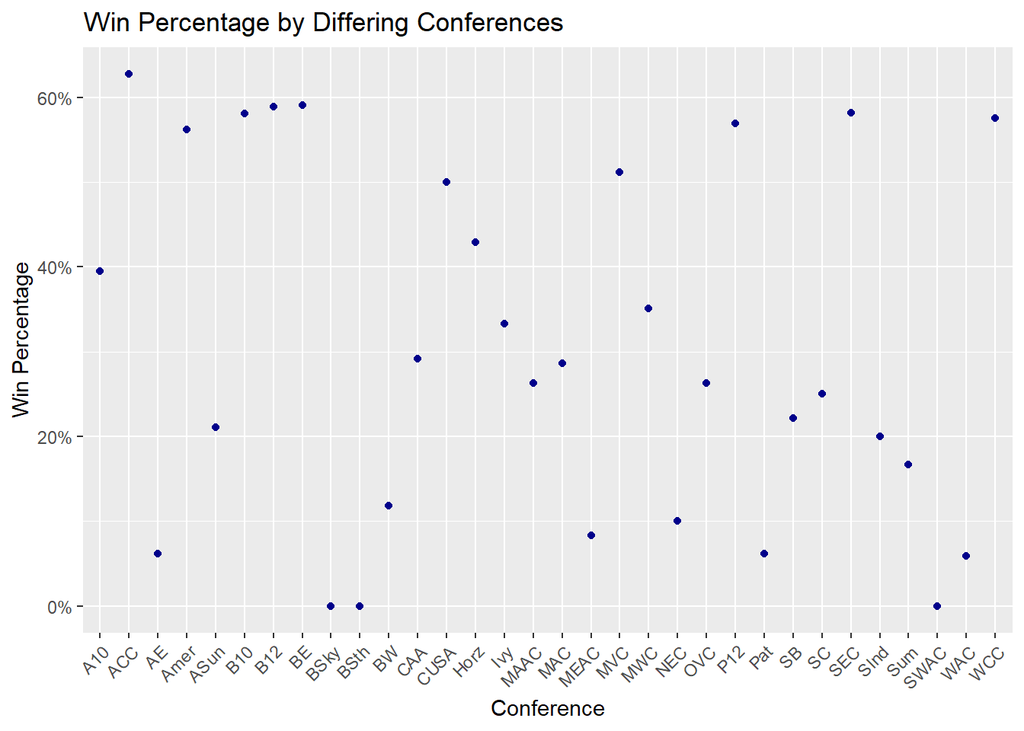

```r
#Create scatterplot for conference win percentage
ggplot(conf_results, aes(x = Conference, y = WinPercent))+
  geom_point(color = "darkblue")+
  scale_x_discrete(guide = guide_axis(angle = 45))+
  scale_y_continuous(
    labels = label_percent(scale = 100)
  ) +
  labs(
    title = "Win Percentage by Differing Conferences",
    x = "Conference",
    y = "Win Percentage"
  )
```

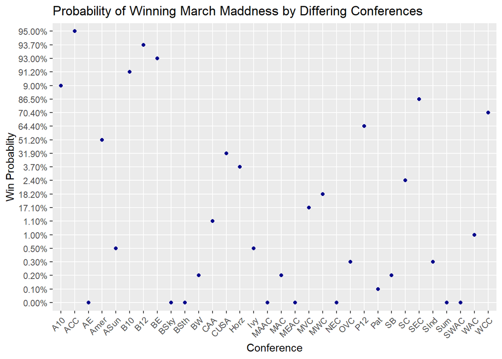

```r
#Create scatterplot for conference win probability
ggplot(conf_results, aes(x = Conference, y = ProbChamp))+
  geom_point(color = "darkblue")+
  scale_x_discrete(guide = guide_axis(angle = 45))+
  labs(
    title = "Probability of Winning March Maddness by Differing Conferences",
    x = "Conference",
    y = "Win Probablity"
  )
```

```r
advantages <- scoring_margins |>
  left_join( home , by = c( "Season" = "Year" , "Team" ) ) |>
  rename( "HomeAdv" = "Home" , "AwayAdv" = "Away" ) |>
  select( Season, TeamID, Team, Seed, Round,  HomeAdv, AwayAdv, WinPercent )
```

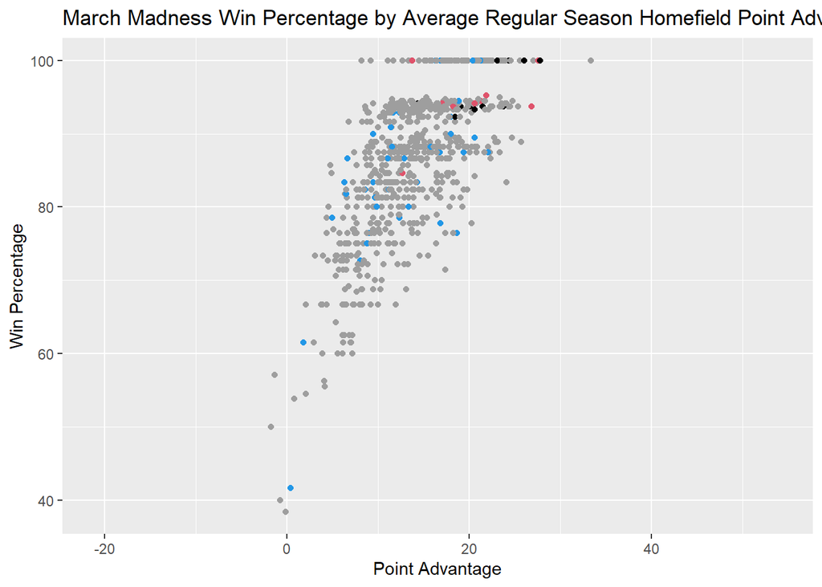

```r
advantages |> ggplot(aes(
  HomeAdv,
  WinPercent)) +
  geom_point(color = advantages$Round) +
  labs(
    title = "March Madness Win Percentage by Average Regular Season Homefield Point Advantage",
    x = "Point Advantage",
    y = "Win Percentage"
  )
```

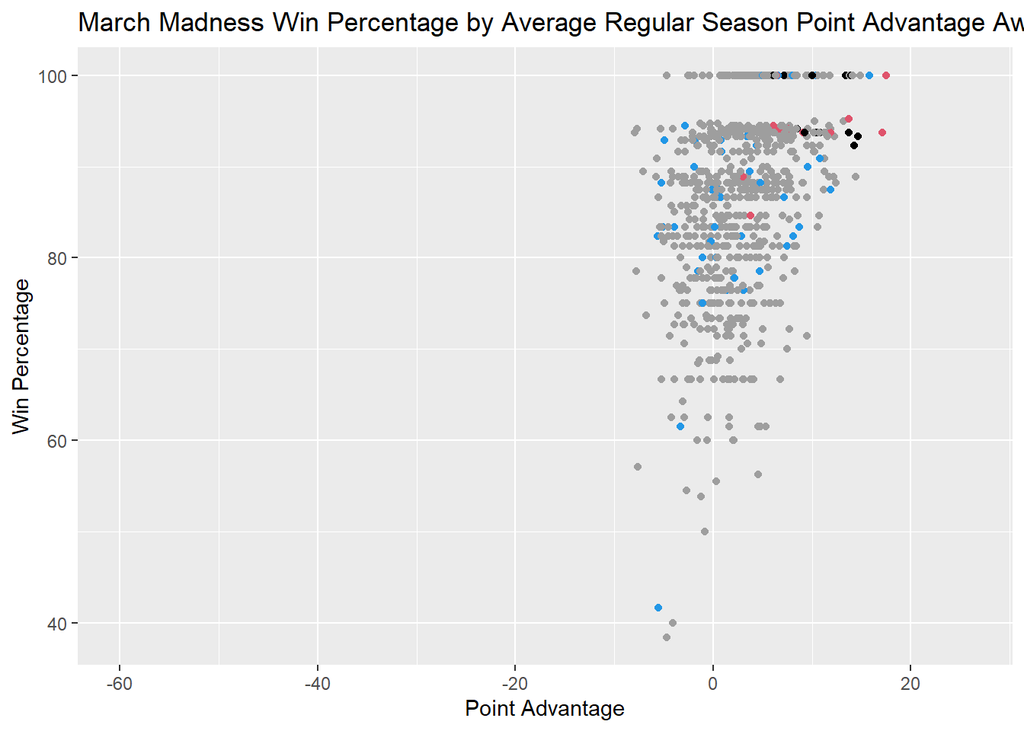

```r
advantages |> ggplot(aes(
  AwayAdv,
  WinPercent)) +
  geom_point(color = advantages$Round) +
  labs(
    title = "March Madness Win Percentage by Average Regular Season Point Advantage Away or at Nuetral Sites",
    x = "Point Advantage",
    y = "Win Percentage"
  )
```

# ANOVA

Here we set up and run the model:

```r
home_adv_model <- aov( WinPercent ~ HomeAdv , data = advantages )

summary( home_adv_model )
```

```
             Df Sum Sq Mean Sq F value Pr(>F)
HomeAdv       1  34342   34342   638.1 <2e-16 ***
Residuals   714  38429      54
---
Signif. codes:  0 '***' 0.001 '**' 0.01 '*' 0.05 '.' 0.1 ' ' 1
5257 observations deleted due to missingness
```

Given the low p-value, we reject the null hypothesis and conclude that the two factors are related in some way.

## Reflect

This data does not do a good job predicting March Madness success. At least, not the limited number of combinations which we explored. March Madness success is the result of many factors, meaning a large-scale, multi-factor ML model would be appropriate for such an analysis. We will return to such an analysis after we learn to do so.However, we can advise that one wanting to predict March Madness success would look at a team’s average regular-season point advantage, both home and away, as a possible easy-to-track predictive variable.